# Análisis comparativo de una muestra con proteinas de referencia

Esto se debe a que, sin filtrar según el Fold-Change, un alto número de las proteinas que obtienen un p-valor ajustado menor que 0.05 tienen una tasa de cambio muy pequeña ya que realmente no hay cambio.

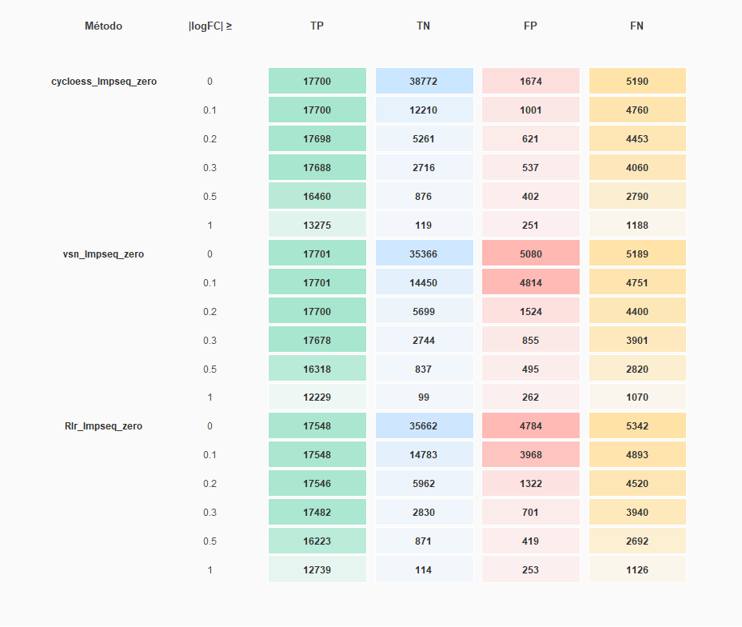

(a) Valores MNAR imputados mediante zero

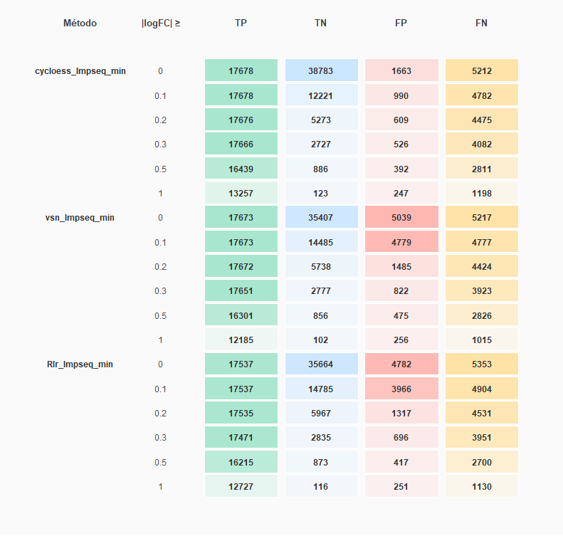

(b) Valores MNAR imputados mediante min

Figure 6: **Tabla de cuantificación de verdaderos positivos, verdaderos negativos, falsos positivos y falsos negativos.**

Al extraer las proteinas con un |logFC| > 0.2 y un p-valor ajustado < 0.05, se obtiene que el porcentaje de proteinas compartidas entre los diferentes métodos de normalización de los datos es superior, alcanzando el 78% de proteinas comunes para ambos métodos de imputación de valores MNAR (Figure 7). Así, se puede observar que el diagrama muestra círculos más concentricos y un menor número de proteinas compartidas entre las rescatadas de la imputación con Rlr y vsn. Esto indica que el número de falsos positivos que se generaban con los métodos Rlr y vsn que estos compartian (18%) se ven filtrados por la tasa de cambio.

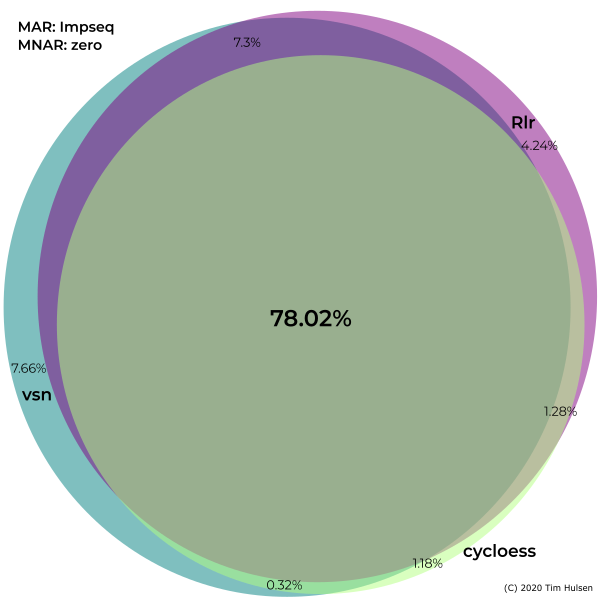

(a) VennDiagram zero logFC

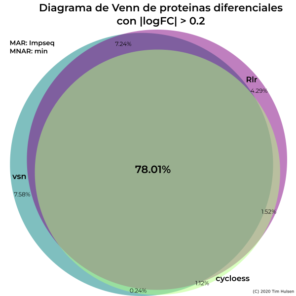

(b) VennDiagram min logFC

Figure 7: **Diagramas de Venn para las proteinas diferencialmente expresadas con un valor de logaritmo en base dos una tasa de cambio superior al 0.2 e inferior al 0.2**

### Pattern profiler

Se obtiene el pattern profiler para el conjunto de proteinas diferenciales obtenidas mediante normalización por cycloess, ya que es el método que posteriormente devuelve menos falsos positivos. El método de imputación de valores ausentes MAR será Impseq y el de MNAR es zero. Se ha ecigido que el mínimo de pertenencia a un cluster debe ser superior a 0.7.

```r
pp_cycloess_Impseq_zero <- process_proteomics(preproc_data_spikein,
                                       norm_method = "cycloess",
                                       imp_method = "combo",
                                       mar_method = "Impseq",
                                       mnar_method = "zero",
                                       verbose = FALSE)

pattern_profile_zero <- pattern_profiler_analysis(
                            se_proc = pp_cycloess_Impseq_zero$se_proc,
                            DEPs_results = pp_cycloess_Impseq_zero$DEPs_results,
                            assay_name = "Impseq_zero",
                            filter_mode = "any",
                            c_range = 2:8,
                            verbose = FALSE)
centroid_plot <- cluster_centroids_highchart(
  pattern_profile_zero$long_output,
  conditions = pattern_profile_zero$conditions,
  min_membership = 0.70,
  centroid_summary = "median",
  title = "Pattern Profiler cluster centroids"
)
```

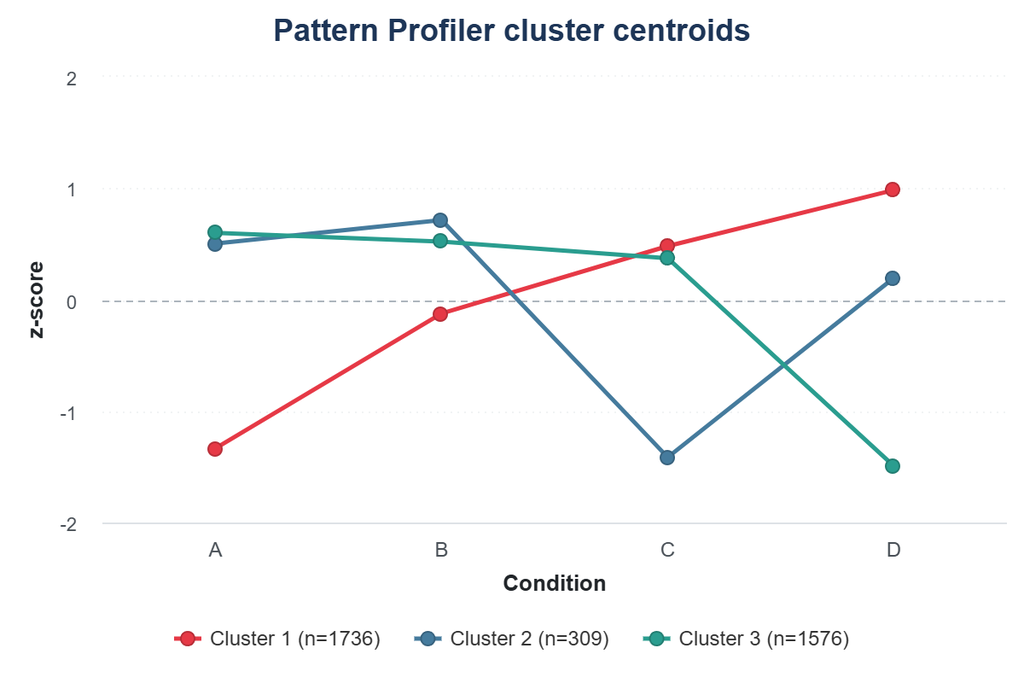

Figure 8: Pattern profile de las proteinas expresadas de manera diferencial en las diferentes muestras

Este gráfico permite analizar como cambian las proteinas a diferentes tiempos o entre diferentes condiciones, permitiendo seleccionar proteinas que siguen una misma tendencia y pueden estar relacionadas.

# Discusión y Conclusiones.

La veracidad de los resultados depende de los métodos de normalización e imputación seleccionados. Evaluar la capacidad de los diferentes métodos de devolver el mayor número de verdaderos positivos y el menor número de falsos positivos, es crucial para la posterior interpretación funcional. Se ha observado que la selección de un método u otro puede suponer una diferencia en el resultado que se obtiene, dando lugar a una interpretación funcional errónea. Por ello, es conveniente analizar como de relevantes son las proteínas diferenciales para cada condición mediante un diagrama de Venn que demuestre que aquellas proteínas encontradas como diferenciales, realmente son relevantes biológicamente y no son artefactos causados por la manipulación de los datos.

Por otro lado, se ha observado que establecer un filtro de logFC dependiente del conjunto de datos empleado es crucial. Esto permite eliminar un alto número de falsos positivos manteniendo los grupos proteicos que se expresan de manera diferencial de manera real.

Si bien esto no es posible cuando los datos a analizar son reales, dado que no contamos con proteínas spike-in, tras analizar diferentes conjuntos de datos, se puede ir conociendo que método de normalización o imputación podría ser más adecuado para el análisis de datos reales. Como, por ejemplo, se ha observado que, en ambos casos, el método cycloess tiende a devolver un bajo número de falsos positivos.

# Referencias Bibliográficas.